# Risk Factor Analysis

## Outcome Variable

**Outcome Variable:** haz

## Predictor Variables

**Intervention Variable:** earlybf

**Adjustment Set:**

unadjusted

## Stratifying Variables

The analysis was stratified on these variable(s):

- agecat
- studyid
- country

## Data Summary

| agecat | studyid | country | earlybf | n_cell | n |
| --- | --- | --- | --- | --- | --- |
| Birth | ki0047075b-MAL-ED | BANGLADESH | 1 | 159 | 256 |
| Birth | ki0047075b-MAL-ED | BANGLADESH | 0 | 97 | 256 |
| Birth | ki0047075b-MAL-ED | BRAZIL | 1 | 83 | 191 |
| Birth | ki0047075b-MAL-ED | BRAZIL | 0 | 108 | 191 |
| Birth | ki0047075b-MAL-ED | INDIA | 1 | 124 | 205 |
| Birth | ki0047075b-MAL-ED | INDIA | 0 | 81 | 205 |
| Birth | ki0047075b-MAL-ED | NEPAL | 1 | 79 | 173 |
| Birth | ki0047075b-MAL-ED | NEPAL | 0 | 94 | 173 |
| Birth | ki0047075b-MAL-ED | PERU | 1 | 214 | 287 |
| Birth | ki0047075b-MAL-ED | PERU | 0 | 73 | 287 |
| Birth | ki0047075b-MAL-ED | SOUTH AFRICA | 1 | 155 | 247 |
| Birth | ki0047075b-MAL-ED | SOUTH AFRICA | 0 | 92 | 247 |
| Birth | ki0047075b-MAL-ED | TANZANIA, UNITED REPUBLIC OF | 1 | 111 | 123 |
| Birth | ki0047075b-MAL-ED | TANZANIA, UNITED REPUBLIC OF | 0 | 12 | 123 |
| Birth | ki1000109-EE | PAKISTAN | 1 | 1 | 2 |
| Birth | ki1000109-EE | PAKISTAN | 0 | 1 | 2 |
| Birth | ki1000304b-SAS-CompFeed | INDIA | 1 | 14 | 177 |
| Birth | ki1000304b-SAS-CompFeed | INDIA | 0 | 163 | 177 |
| Birth | ki1017093c-NIH-Crypto | BANGLADESH | 1 | 23 | 27 |
| Birth | ki1017093c-NIH-Crypto | BANGLADESH | 0 | 4 | 27 |
| Birth | ki1126311-ZVITAMBO | ZIMBABWE | 1 | 6533 | 12319 |
| Birth | ki1126311-ZVITAMBO | ZIMBABWE | 0 | 5786 | 12319 |
| Birth | kiGH5241-JiVitA-3 | BANGLADESH | 1 | 212 | 19541 |
| Birth | kiGH5241-JiVitA-3 | BANGLADESH | 0 | 19329 | 19541 |
| Birth | kiGH5241-JiVitA-4 | BANGLADESH | 1 | 566 | 822 |
| Birth | kiGH5241-JiVitA-4 | BANGLADESH | 0 | 256 | 822 |
| 6 months | ki0047075b-MAL-ED | BANGLADESH | 1 | 147 | 240 |
| 6 months | ki0047075b-MAL-ED | BANGLADESH | 0 | 93 | 240 |
| 6 months | ki0047075b-MAL-ED | BRAZIL | 1 | 95 | 209 |
| 6 months | ki0047075b-MAL-ED | BRAZIL | 0 | 114 | 209 |
| 6 months | ki0047075b-MAL-ED | INDIA | 1 | 140 | 236 |
| 6 months | ki0047075b-MAL-ED | INDIA | 0 | 96 | 236 |
| 6 months | ki0047075b-MAL-ED | NEPAL | 1 | 96 | 236 |
| 6 months | ki0047075b-MAL-ED | NEPAL | 0 | 140 | 236 |
| 6 months | ki0047075b-MAL-ED | PERU | 1 | 202 | 273 |
| 6 months | ki0047075b-MAL-ED | PERU | 0 | 71 | 273 |
| 6 months | ki0047075b-MAL-ED | SOUTH AFRICA | 1 | 156 | 250 |
| 6 months | ki0047075b-MAL-ED | SOUTH AFRICA | 0 | 94 | 250 |
| 6 months | ki0047075b-MAL-ED | TANZANIA, UNITED REPUBLIC OF | 1 | 205 | 247 |
| 6 months | ki0047075b-MAL-ED | TANZANIA, UNITED REPUBLIC OF | 0 | 42 | 247 |
| 6 months | ki1000109-EE | PAKISTAN | 1 | 68 | 372 |
| 6 months | ki1000109-EE | PAKISTAN | 0 | 304 | 372 |
| 6 months | ki1000304b-SAS-CompFeed | INDIA | 1 | 98 | 1336 |
| 6 months | ki1000304b-SAS-CompFeed | INDIA | 0 | 1238 | 1336 |
| 6 months | ki1017093c-NIH-Crypto | BANGLADESH | 1 | 619 | 715 |
| 6 months | ki1017093c-NIH-Crypto | BANGLADESH | 0 | 96 | 715 |
| 6 months | ki1113344-GMS-Nepal | NEPAL | 1 | 151 | 510 |
| 6 months | ki1113344-GMS-Nepal | NEPAL | 0 | 359 | 510 |
| 6 months | ki1126311-ZVITAMBO | ZIMBABWE | 1 | 3968 | 7365 |
| 6 months | ki1126311-ZVITAMBO | ZIMBABWE | 0 | 3397 | 7365 |
| 6 months | kiGH5241-JiVitA-3 | BANGLADESH | 1 | 35 | 16811 |
| 6 months | kiGH5241-JiVitA-3 | BANGLADESH | 0 | 16776 | 16811 |
| 6 months | kiGH5241-JiVitA-4 | BANGLADESH | 1 | 3094 | 4831 |
| 6 months | kiGH5241-JiVitA-4 | BANGLADESH | 0 | 1737 | 4831 |
| 24 months | ki0047075b-MAL-ED | BANGLADESH | 1 | 128 | 211 |
| 24 months | ki0047075b-MAL-ED | BANGLADESH | 0 | 83 | 211 |
| 24 months | ki0047075b-MAL-ED | BRAZIL | 1 | 80 | 169 |
| 24 months | ki0047075b-MAL-ED | BRAZIL | 0 | 89 | 169 |
| 24 months | ki0047075b-MAL-ED | INDIA | 1 | 134 | 227 |
| 24 months | ki0047075b-MAL-ED | INDIA | 0 | 93 | 227 |
| 24 months | ki0047075b-MAL-ED | NEPAL | 1 | 95 | 228 |
| 24 months | ki0047075b-MAL-ED | NEPAL | 0 | 133 | 228 |
| 24 months | ki0047075b-MAL-ED | PERU | 1 | 149 | 201 |
| 24 months | ki0047075b-MAL-ED | PERU | 0 | 52 | 201 |
| 24 months | ki0047075b-MAL-ED | SOUTH AFRICA | 1 | 144 | 235 |
| 24 months | ki0047075b-MAL-ED | SOUTH AFRICA | 0 | 91 | 235 |
| 24 months | ki0047075b-MAL-ED | TANZANIA, UNITED REPUBLIC OF | 1 | 180 | 214 |
| 24 months | ki0047075b-MAL-ED | TANZANIA, UNITED REPUBLIC OF | 0 | 34 | 214 |
| 24 months | ki1017093c-NIH-Crypto | BANGLADESH | 1 | 443 | 514 |
| 24 months | ki1017093c-NIH-Crypto | BANGLADESH | 0 | 71 | 514 |
| 24 months | ki1113344-GMS-Nepal | NEPAL | 1 | 136 | 455 |
| 24 months | ki1113344-GMS-Nepal | NEPAL | 0 | 319 | 455 |
| 24 months | ki1126311-ZVITAMBO | ZIMBABWE | 1 | 214 | 399 |
| 24 months | ki1126311-ZVITAMBO | ZIMBABWE | 0 | 185 | 399 |
| 24 months | kiGH5241-JiVitA-3 | BANGLADESH | 1 | 1 | 8632 |
| 24 months | kiGH5241-JiVitA-3 | BANGLADESH | 0 | 8631 | 8632 |
| 24 months | kiGH5241-JiVitA-4 | BANGLADESH | 1 | 3042 | 4752 |
| 24 months | kiGH5241-JiVitA-4 | BANGLADESH | 0 | 1710 | 4752 |

The following strata were considered:

- agecat: 24 months, studyid: ki0047075b-MAL-ED, country: BANGLADESH
- agecat: 24 months, studyid: ki0047075b-MAL-ED, country: BRAZIL
- agecat: 24 months, studyid: ki0047075b-MAL-ED, country: INDIA
- agecat: 24 months, studyid: ki0047075b-MAL-ED, country: NEPAL
- agecat: 24 months, studyid: ki0047075b-MAL-ED, country: PERU
- agecat: 24 months, studyid: ki0047075b-MAL-ED, country: SOUTH AFRICA
- agecat: 24 months, studyid: ki0047075b-MAL-ED, country: TANZANIA, UNITED REPUBLIC OF
- agecat: 24 months, studyid: ki1017093c-NIH-Crypto, country: BANGLADESH
- agecat: 24 months, studyid: ki1113344-GMS-Nepal, country: NEPAL
- agecat: 24 months, studyid: ki1126311-ZVITAMBO, country: ZIMBABWE
- agecat: 24 months, studyid: kiGH5241-JiVitA-3, country: BANGLADESH
- agecat: 24 months, studyid: kiGH5241-JiVitA-4, country: BANGLADESH
- agecat: 6 months, studyid: ki0047075b-MAL-ED, country: BANGLADESH
- agecat: 6 months, studyid: ki0047075b-MAL-ED, country: BRAZIL
- agecat: 6 months, studyid: ki0047075b-MAL-ED, country: INDIA
- agecat: 6 months, studyid: ki0047075b-MAL-ED, country: NEPAL
- agecat: 6 months, studyid: ki0047075b-MAL-ED, country: PERU
- agecat: 6 months, studyid: ki0047075b-MAL-ED, country: SOUTH AFRICA
- agecat: 6 months, studyid: ki0047075b-MAL-ED, country: TANZANIA, UNITED REPUBLIC OF
- agecat: 6 months, studyid: ki1000109-EE, country: PAKISTAN
- agecat: 6 months, studyid: ki1000304b-SAS-CompFeed, country: INDIA
- agecat: 6 months, studyid: ki1017093c-NIH-Crypto, country: BANGLADESH
- agecat: 6 months, studyid: ki1113344-GMS-Nepal, country: NEPAL
- agecat: 6 months, studyid: ki1126311-ZVITAMBO, country: ZIMBABWE
- agecat: 6 months, studyid: kiGH5241-JiVitA-3, country: BANGLADESH
- agecat: 6 months, studyid: kiGH5241-JiVitA-4, country: BANGLADESH
- agecat: Birth, studyid: ki0047075b-MAL-ED, country: BANGLADESH
- agecat: Birth, studyid: ki0047075b-MAL-ED, country: BRAZIL
- agecat: Birth, studyid: ki0047075b-MAL-ED, country: INDIA
- agecat: Birth, studyid: ki0047075b-MAL-ED, country: NEPAL
- agecat: Birth, studyid: ki0047075b-MAL-ED, country: PERU
- agecat: Birth, studyid: ki0047075b-MAL-ED, country: SOUTH AFRICA
- agecat: Birth, studyid: ki0047075b-MAL-ED, country: TANZANIA, UNITED REPUBLIC OF
- agecat: Birth, studyid: ki1000109-EE, country: PAKISTAN
- agecat: Birth, studyid: ki1000304b-SAS-CompFeed, country: INDIA
- agecat: Birth, studyid: ki1017093c-NIH-Crypto, country: BANGLADESH
- agecat: Birth, studyid: ki1126311-ZVITAMBO, country: ZIMBABWE
- agecat: Birth, studyid: kiGH5241-JiVitA-3, country: BANGLADESH
- agecat: Birth, studyid: kiGH5241-JiVitA-4, country: BANGLADESH

### Dropped Strata

Some strata were dropped due to rare outcomes:

- agecat: Birth, studyid: ki1000109-EE, country: PAKISTAN
- agecat: Birth, studyid: ki1017093c-NIH-Crypto, country: BANGLADESH
- agecat: 24 months, studyid: kiGH5241-JiVitA-3, country: BANGLADESH

## Methods Detail

We’re interested in the causal parameters $E[Y_a]$ for all values of $a \in \mathcal{A}$. These parameters represent the mean outcome if, possibly contrary to fact, we intervened to set all units to have $A=a$. Under the randomization and positivity assumptions, these are identified by the statistical parameters $\psi_a=E_W[E_{Y|A,W}(Y|A=a,W)]$. In addition, we’re interested in the mean of $Y$, $E[Y]$ under no intervention (the observed mean). We will estimate these parameters by using SuperLearner to fit the relevant likelihood factors – $E_{Y|A,W}(Y|A=a,W)$ and $p(A=a|W)$, and then updating our likelihood fit using a joint TMLE.

For unadjusted analyses ($W=\{\}$), initial likelihoods were estimated using Lrnr_glm to estimate the simple $E(Y|A)$ and Lrnr_mean to estimate $p(A)$. For adjusted analyses, a small library containing Lrnr_glmnet, Lrnr_xgboost, and Lrnr_mean was used.

Having estimated these parameters, we will then use the delta method to estimate relative risks and attributable risks relative to a prespecified baseline level of $A$.

# Results Detail

## Results Plots

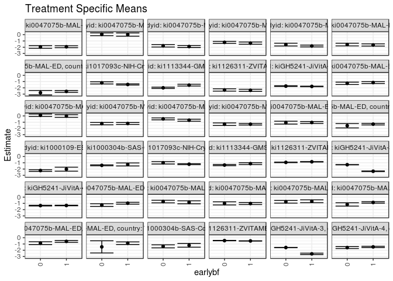

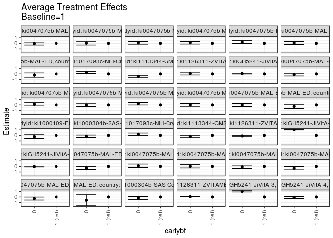

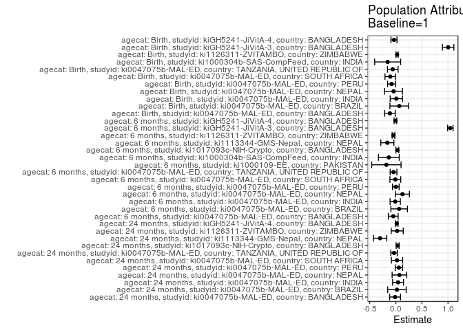

## Results Table

### Parameter: TSM

| agecat | studyid | country | intervention_level | baseline_level | estimate | ci_lower | ci_upper |
| --- | --- | --- | --- | --- | --- | --- | --- |
| Birth | ki0047075b-MAL-ED | BANGLADESH | 1 | NA | -0.9757233 | -1.1281269 | -0.8233196 |
| Birth | ki0047075b-MAL-ED | BANGLADESH | 0 | NA | -1.2710309 | -1.4856022 | -1.0564596 |
| Birth | ki0047075b-MAL-ED | BRAZIL | 1 | NA | -0.8280723 | -1.0673614 | -0.5887832 |
| Birth | ki0047075b-MAL-ED | BRAZIL | 0 | NA | -0.7093519 | -0.9165880 | -0.5021157 |
| Birth | ki0047075b-MAL-ED | INDIA | 1 | NA | -1.0249194 | -1.1875996 | -0.8622391 |
| Birth | ki0047075b-MAL-ED | INDIA | 0 | NA | -0.9969136 | -1.2485576 | -0.7452696 |
| Birth | ki0047075b-MAL-ED | NEPAL | 1 | NA | -0.6668354 | -0.8980380 | -0.4356329 |
| Birth | ki0047075b-MAL-ED | NEPAL | 0 | NA | -0.7442553 | -0.9571124 | -0.5313983 |
| Birth | ki0047075b-MAL-ED | PERU | 1 | NA | -0.8515421 | -0.9726039 | -0.7304802 |
| Birth | ki0047075b-MAL-ED | PERU | 0 | NA | -1.1687671 | -1.4344710 | -0.9030633 |
| Birth | ki0047075b-MAL-ED | SOUTH AFRICA | 1 | NA | -0.5849032 | -0.7353974 | -0.4344091 |
| Birth | ki0047075b-MAL-ED | SOUTH AFRICA | 0 | NA | -0.8676087 | -1.0894452 | -0.6457721 |
| Birth | ki0047075b-MAL-ED | TANZANIA, UNITED REPUBLIC OF | 1 | NA | -0.8765766 | -1.0847237 | -0.6684295 |
| Birth | ki0047075b-MAL-ED | TANZANIA, UNITED REPUBLIC OF | 0 | NA | -1.4633333 | -2.4355886 | -0.4910780 |
| Birth | ki1000304b-SAS-CompFeed | INDIA | 1 | NA | -1.2107143 | -1.5130885 | -0.9083401 |
| Birth | ki1000304b-SAS-CompFeed | INDIA | 0 | NA | -1.3795092 | -1.6220416 | -1.1369768 |
| Birth | ki1126311-ZVITAMBO | ZIMBABWE | 1 | NA | -0.5152824 | -0.5438271 | -0.4867378 |
| Birth | ki1126311-ZVITAMBO | ZIMBABWE | 0 | NA | -0.4611614 | -0.4947363 | -0.4275865 |
| Birth | kiGH5241-JiVitA-3 | BANGLADESH | 1 | NA | -2.5772641 | -2.6878493 | -2.4666790 |
| Birth | kiGH5241-JiVitA-3 | BANGLADESH | 0 | NA | -1.5642998 | -1.5841960 | -1.5444035 |
| Birth | kiGH5241-JiVitA-4 | BANGLADESH | 1 | NA | -1.4627739 | -1.5635979 | -1.3619498 |
| Birth | kiGH5241-JiVitA-4 | BANGLADESH | 0 | NA | -1.5748047 | -1.7282248 | -1.4213845 |
| 6 months | ki0047075b-MAL-ED | BANGLADESH | 1 | NA | -1.1579138 | -1.3079649 | -1.0078628 |
| 6 months | ki0047075b-MAL-ED | BANGLADESH | 0 | NA | -1.2828495 | -1.4726138 | -1.0930852 |
| 6 months | ki0047075b-MAL-ED | BRAZIL | 1 | NA | -0.0133684 | -0.2326762 | 0.2059393 |
| 6 months | ki0047075b-MAL-ED | BRAZIL | 0 | NA | 0.1046784 | -0.0853754 | 0.2947322 |
| 6 months | ki0047075b-MAL-ED | INDIA | 1 | NA | -1.2095119 | -1.3624204 | -1.0566034 |
| 6 months | ki0047075b-MAL-ED | INDIA | 0 | NA | -1.2361979 | -1.4232004 | -1.0491954 |
| 6 months | ki0047075b-MAL-ED | NEPAL | 1 | NA | -0.6885243 | -0.8530343 | -0.5240143 |
| 6 months | ki0047075b-MAL-ED | NEPAL | 0 | NA | -0.4736548 | -0.6248834 | -0.3224261 |
| 6 months | ki0047075b-MAL-ED | PERU | 1 | NA | -1.3275165 | -1.4548945 | -1.2001385 |
| 6 months | ki0047075b-MAL-ED | PERU | 0 | NA | -1.3247653 | -1.5300439 | -1.1194866 |
| 6 months | ki0047075b-MAL-ED | SOUTH AFRICA | 1 | NA | -1.0512393 | -1.2049782 | -0.8975005 |
| 6 months | ki0047075b-MAL-ED | SOUTH AFRICA | 0 | NA | -1.0743706 | -1.3030216 | -0.8457196 |
| 6 months | ki0047075b-MAL-ED | TANZANIA, UNITED REPUBLIC OF | 1 | NA | -1.3172520 | -1.4447796 | -1.1897245 |
| 6 months | ki0047075b-MAL-ED | TANZANIA, UNITED REPUBLIC OF | 0 | NA | -1.5693651 | -1.9200719 | -1.2186583 |
| 6 months | ki1000109-EE | PAKISTAN | 1 | NA | -2.0208088 | -2.3380317 | -1.7035859 |
| 6 months | ki1000109-EE | PAKISTAN | 0 | NA | -2.2406579 | -2.3728850 | -2.1084308 |
| 6 months | ki1000304b-SAS-CompFeed | INDIA | 1 | NA | -1.2686735 | -1.5069719 | -1.0303750 |
| 6 months | ki1000304b-SAS-CompFeed | INDIA | 0 | NA | -1.4123990 | -1.4871070 | -1.3376911 |
| 6 months | ki1017093c-NIH-Crypto | BANGLADESH | 1 | NA | -1.2285137 | -1.3049997 | -1.1520277 |
| 6 months | ki1017093c-NIH-Crypto | BANGLADESH | 0 | NA | -1.0063021 | -1.2011819 | -0.8114223 |
| 6 months | ki1113344-GMS-Nepal | NEPAL | 1 | NA | -1.1379029 | -1.2871532 | -0.9886526 |
| 6 months | ki1113344-GMS-Nepal | NEPAL | 0 | NA | -1.3670427 | -1.4640921 | -1.2699934 |
| 6 months | ki1126311-ZVITAMBO | ZIMBABWE | 1 | NA | -0.8400731 | -0.8773156 | -0.8028305 |
| 6 months | ki1126311-ZVITAMBO | ZIMBABWE | 0 | NA | -0.9372005 | -0.9783764 | -0.8960245 |
| 6 months | kiGH5241-JiVitA-3 | BANGLADESH | 1 | NA | -2.3574286 | -2.4045861 | -2.3102710 |
| 6 months | kiGH5241-JiVitA-3 | BANGLADESH | 0 | NA | -1.3109144 | -1.3345766 | -1.2872522 |
| 6 months | kiGH5241-JiVitA-4 | BANGLADESH | 1 | NA | -1.3382708 | -1.3839008 | -1.2926409 |
| 6 months | kiGH5241-JiVitA-4 | BANGLADESH | 0 | NA | -1.3564134 | -1.4152717 | -1.2975550 |
| 24 months | ki0047075b-MAL-ED | BANGLADESH | 1 | NA | -1.9245703 | -2.0800940 | -1.7690466 |
| 24 months | ki0047075b-MAL-ED | BANGLADESH | 0 | NA | -1.9590361 | -2.1723110 | -1.7457613 |
| 24 months | ki0047075b-MAL-ED | BRAZIL | 1 | NA | 0.0198125 | -0.2360963 | 0.2757213 |
| 24 months | ki0047075b-MAL-ED | BRAZIL | 0 | NA | 0.0616292 | -0.1571691 | 0.2804276 |
| 24 months | ki0047075b-MAL-ED | INDIA | 1 | NA | -1.8900000 | -2.0572797 | -1.7227203 |
| 24 months | ki0047075b-MAL-ED | INDIA | 0 | NA | -1.7821505 | -1.9726508 | -1.5916503 |
| 24 months | ki0047075b-MAL-ED | NEPAL | 1 | NA | -1.3450526 | -1.5208607 | -1.1692445 |
| 24 months | ki0047075b-MAL-ED | NEPAL | 0 | NA | -1.2253383 | -1.3883056 | -1.0623711 |
| 24 months | ki0047075b-MAL-ED | PERU | 1 | NA | -1.8097651 | -1.9510791 | -1.6684511 |
| 24 months | ki0047075b-MAL-ED | PERU | 0 | NA | -1.5791346 | -1.8024632 | -1.3558060 |
| 24 months | ki0047075b-MAL-ED | SOUTH AFRICA | 1 | NA | -1.6384375 | -1.8141331 | -1.4627419 |
| 24 months | ki0047075b-MAL-ED | SOUTH AFRICA | 0 | NA | -1.5765385 | -1.7925587 | -1.3605183 |
| 24 months | ki0047075b-MAL-ED | TANZANIA, UNITED REPUBLIC OF | 1 | NA | -2.5725278 | -2.7168892 | -2.4281664 |
| 24 months | ki0047075b-MAL-ED | TANZANIA, UNITED REPUBLIC OF | 0 | NA | -2.7825000 | -3.1395140 | -2.4254860 |
| 24 months | ki1017093c-NIH-Crypto | BANGLADESH | 1 | NA | -1.4652144 | -1.5571544 | -1.3732744 |
| 24 months | ki1017093c-NIH-Crypto | BANGLADESH | 0 | NA | -1.2069014 | -1.3827976 | -1.0310052 |
| 24 months | ki1113344-GMS-Nepal | NEPAL | 1 | NA | -1.5698162 | -1.7139383 | -1.4256941 |
| 24 months | ki1113344-GMS-Nepal | NEPAL | 0 | NA | -1.9977273 | -2.1062810 | -1.8891735 |
| 24 months | ki1126311-ZVITAMBO | ZIMBABWE | 1 | NA | -2.3992056 | -2.5666749 | -2.2317363 |
| 24 months | ki1126311-ZVITAMBO | ZIMBABWE | 0 | NA | -2.3398378 | -2.5237605 | -2.1559152 |
| 24 months | kiGH5241-JiVitA-4 | BANGLADESH | 1 | NA | -1.7769954 | -1.8213824 | -1.7326084 |
| 24 months | kiGH5241-JiVitA-4 | BANGLADESH | 0 | NA | -1.7249532 | -1.7786544 | -1.6712520 |

### Parameter: E(Y)

| agecat | studyid | country | intervention_level | baseline_level | estimate | ci_lower | ci_upper |
| --- | --- | --- | --- | --- | --- | --- | --- |
| Birth | ki0047075b-MAL-ED | BANGLADESH | NA | NA | -1.0876172 | -1.2136298 | -0.9616045 |
| Birth | ki0047075b-MAL-ED | BRAZIL | NA | NA | -0.7609424 | -0.9178311 | -0.6040538 |
| Birth | ki0047075b-MAL-ED | INDIA | NA | NA | -1.0138537 | -1.1537563 | -0.8739510 |
| Birth | ki0047075b-MAL-ED | NEPAL | NA | NA | -0.7089017 | -0.8656064 | -0.5521971 |
| Birth | ki0047075b-MAL-ED | PERU | NA | NA | -0.9322300 | -1.0461262 | -0.8183337 |
| Birth | ki0047075b-MAL-ED | SOUTH AFRICA | NA | NA | -0.6902024 | -0.8168430 | -0.5635618 |
| Birth | ki0047075b-MAL-ED | TANZANIA, UNITED REPUBLIC OF | NA | NA | -0.9338211 | -1.1465079 | -0.7211344 |
| Birth | ki1000304b-SAS-CompFeed | INDIA | NA | NA | -1.3661582 | -1.6025814 | -1.1297350 |
| Birth | ki1126311-ZVITAMBO | ZIMBABWE | NA | NA | -0.4898628 | -0.5117273 | -0.4679983 |
| Birth | kiGH5241-JiVitA-3 | BANGLADESH | NA | NA | -1.5752894 | -1.5950861 | -1.5554927 |
| Birth | kiGH5241-JiVitA-4 | BANGLADESH | NA | NA | -1.4976642 | -1.5817349 | -1.4135935 |
| 6 months | ki0047075b-MAL-ED | BANGLADESH | NA | NA | -1.2063264 | -1.3242819 | -1.0883709 |
| 6 months | ki0047075b-MAL-ED | BRAZIL | NA | NA | 0.0510207 | -0.0930194 | 0.1950608 |
| 6 months | ki0047075b-MAL-ED | INDIA | NA | NA | -1.2203672 | -1.3387619 | -1.1019726 |
| 6 months | ki0047075b-MAL-ED | NEPAL | NA | NA | -0.5610593 | -0.6737915 | -0.4483272 |
| 6 months | ki0047075b-MAL-ED | PERU | NA | NA | -1.3268010 | -1.4351217 | -1.2184802 |
| 6 months | ki0047075b-MAL-ED | SOUTH AFRICA | NA | NA | -1.0599367 | -1.1887637 | -0.9311096 |
| 6 months | ki0047075b-MAL-ED | TANZANIA, UNITED REPUBLIC OF | NA | NA | -1.3601215 | -1.4821830 | -1.2380600 |
| 6 months | ki1000109-EE | PAKISTAN | NA | NA | -2.2004704 | -2.3234073 | -2.0775336 |
| 6 months | ki1000304b-SAS-CompFeed | INDIA | NA | NA | -1.4018563 | -1.4810585 | -1.3226541 |
| 6 months | ki1017093c-NIH-Crypto | BANGLADESH | NA | NA | -1.1986783 | -1.2700937 | -1.1272630 |
| 6 months | ki1113344-GMS-Nepal | NEPAL | NA | NA | -1.2991993 | -1.3810668 | -1.2173319 |
| 6 months | ki1126311-ZVITAMBO | ZIMBABWE | NA | NA | -0.8848717 | -0.9125215 | -0.8572218 |
| 6 months | kiGH5241-JiVitA-3 | BANGLADESH | NA | NA | -1.3130932 | -1.3362359 | -1.2899505 |
| 6 months | kiGH5241-JiVitA-4 | BANGLADESH | NA | NA | -1.3447940 | -1.3820261 | -1.3075620 |
| 24 months | ki0047075b-MAL-ED | BANGLADESH | NA | NA | -1.9381280 | -2.0644004 | -1.8118555 |
| 24 months | ki0047075b-MAL-ED | BRAZIL | NA | NA | 0.0418343 | -0.1253834 | 0.2090521 |
| 24 months | ki0047075b-MAL-ED | INDIA | NA | NA | -1.8458150 | -1.9718703 | -1.7197596 |
| 24 months | ki0047075b-MAL-ED | NEPAL | NA | NA | -1.2752193 | -1.3954783 | -1.1549603 |
| 24 months | ki0047075b-MAL-ED | PERU | NA | NA | -1.7500995 | -1.8705474 | -1.6296516 |
| 24 months | ki0047075b-MAL-ED | SOUTH AFRICA | NA | NA | -1.6144681 | -1.7508611 | -1.4780751 |
| 24 months | ki0047075b-MAL-ED | TANZANIA, UNITED REPUBLIC OF | NA | NA | -2.6058879 | -2.7403043 | -2.4714714 |
| 24 months | ki1017093c-NIH-Crypto | BANGLADESH | NA | NA | -1.4295331 | -1.5127726 | -1.3462935 |
| 24 months | ki1113344-GMS-Nepal | NEPAL | NA | NA | -1.8698242 | -1.9591140 | -1.7805343 |
| 24 months | ki1126311-ZVITAMBO | ZIMBABWE | NA | NA | -2.3716792 | -2.4955680 | -2.2477904 |
| 24 months | kiGH5241-JiVitA-4 | BANGLADESH | NA | NA | -1.7582681 | -1.7937283 | -1.7228079 |

### Parameter: ATE

| agecat | studyid | country | intervention_level | baseline_level | estimate | ci_lower | ci_upper |
| --- | --- | --- | --- | --- | --- | --- | --- |
| Birth | ki0047075b-MAL-ED | BANGLADESH | 1 | 1 | 0.0000000 | 0.0000000 | 0.0000000 |
| Birth | ki0047075b-MAL-ED | BANGLADESH | 0 | 1 | -0.2953077 | -0.5584952 | -0.0321201 |
| Birth | ki0047075b-MAL-ED | BRAZIL | 1 | 1 | 0.0000000 | 0.0000000 | 0.0000000 |
| Birth | ki0047075b-MAL-ED | BRAZIL | 0 | 1 | 0.1187204 | -0.1978330 | 0.4352739 |
| Birth | ki0047075b-MAL-ED | INDIA | 1 | 1 | 0.0000000 | 0.0000000 | 0.0000000 |
| Birth | ki0047075b-MAL-ED | INDIA | 0 | 1 | 0.0280058 | -0.2716433 | 0.3276548 |
| Birth | ki0047075b-MAL-ED | NEPAL | 1 | 1 | 0.0000000 | 0.0000000 | 0.0000000 |
| Birth | ki0047075b-MAL-ED | NEPAL | 0 | 1 | -0.0774199 | -0.3916853 | 0.2368456 |
| Birth | ki0047075b-MAL-ED | PERU | 1 | 1 | 0.0000000 | 0.0000000 | 0.0000000 |
| Birth | ki0047075b-MAL-ED | PERU | 0 | 1 | -0.3172251 | -0.6092088 | -0.0252413 |
| Birth | ki0047075b-MAL-ED | SOUTH AFRICA | 1 | 1 | 0.0000000 | 0.0000000 | 0.0000000 |
| Birth | ki0047075b-MAL-ED | SOUTH AFRICA | 0 | 1 | -0.2827055 | -0.5507725 | -0.0146384 |
| Birth | ki0047075b-MAL-ED | TANZANIA, UNITED REPUBLIC OF | 1 | 1 | 0.0000000 | 0.0000000 | 0.0000000 |
| Birth | ki0047075b-MAL-ED | TANZANIA, UNITED REPUBLIC OF | 0 | 1 | -0.5867568 | -1.5810432 | 0.4075297 |
| Birth | ki1000304b-SAS-CompFeed | INDIA | 1 | 1 | 0.0000000 | 0.0000000 | 0.0000000 |
| Birth | ki1000304b-SAS-CompFeed | INDIA | 0 | 1 | -0.1687949 | -0.4353771 | 0.0977873 |
| Birth | ki1126311-ZVITAMBO | ZIMBABWE | 1 | 1 | 0.0000000 | 0.0000000 | 0.0000000 |
| Birth | ki1126311-ZVITAMBO | ZIMBABWE | 0 | 1 | 0.0541210 | 0.0100521 | 0.0981899 |
| Birth | kiGH5241-JiVitA-3 | BANGLADESH | 1 | 1 | 0.0000000 | 0.0000000 | 0.0000000 |
| Birth | kiGH5241-JiVitA-3 | BANGLADESH | 0 | 1 | 1.0129644 | 0.9008784 | 1.1250504 |
| Birth | kiGH5241-JiVitA-4 | BANGLADESH | 1 | 1 | 0.0000000 | 0.0000000 | 0.0000000 |
| Birth | kiGH5241-JiVitA-4 | BANGLADESH | 0 | 1 | -0.1120308 | -0.2965034 | 0.0724417 |
| 6 months | ki0047075b-MAL-ED | BANGLADESH | 1 | 1 | 0.0000000 | 0.0000000 | 0.0000000 |
| 6 months | ki0047075b-MAL-ED | BANGLADESH | 0 | 1 | -0.1249356 | -0.3668567 | 0.1169854 |
| 6 months | ki0047075b-MAL-ED | BRAZIL | 1 | 1 | 0.0000000 | 0.0000000 | 0.0000000 |
| 6 months | ki0047075b-MAL-ED | BRAZIL | 0 | 1 | 0.1180468 | -0.1721537 | 0.4082473 |
| 6 months | ki0047075b-MAL-ED | INDIA | 1 | 1 | 0.0000000 | 0.0000000 | 0.0000000 |
| 6 months | ki0047075b-MAL-ED | INDIA | 0 | 1 | -0.0266860 | -0.2682454 | 0.2148734 |
| 6 months | ki0047075b-MAL-ED | NEPAL | 1 | 1 | 0.0000000 | 0.0000000 | 0.0000000 |
| 6 months | ki0047075b-MAL-ED | NEPAL | 0 | 1 | 0.2148695 | -0.0085888 | 0.4383279 |
| 6 months | ki0047075b-MAL-ED | PERU | 1 | 1 | 0.0000000 | 0.0000000 | 0.0000000 |
| 6 months | ki0047075b-MAL-ED | PERU | 0 | 1 | 0.0027512 | -0.2388362 | 0.2443387 |
| 6 months | ki0047075b-MAL-ED | SOUTH AFRICA | 1 | 1 | 0.0000000 | 0.0000000 | 0.0000000 |
| 6 months | ki0047075b-MAL-ED | SOUTH AFRICA | 0 | 1 | -0.0231313 | -0.2986615 | 0.2523990 |
| 6 months | ki0047075b-MAL-ED | TANZANIA, UNITED REPUBLIC OF | 1 | 1 | 0.0000000 | 0.0000000 | 0.0000000 |
| 6 months | ki0047075b-MAL-ED | TANZANIA, UNITED REPUBLIC OF | 0 | 1 | -0.2521130 | -0.6252867 | 0.1210606 |
| 6 months | ki1000109-EE | PAKISTAN | 1 | 1 | 0.0000000 | 0.0000000 | 0.0000000 |
| 6 months | ki1000109-EE | PAKISTAN | 0 | 1 | -0.2198491 | -0.5635268 | 0.1238286 |
| 6 months | ki1000304b-SAS-CompFeed | INDIA | 1 | 1 | 0.0000000 | 0.0000000 | 0.0000000 |
| 6 months | ki1000304b-SAS-CompFeed | INDIA | 0 | 1 | -0.1437256 | -0.3575331 | 0.0700819 |
| 6 months | ki1017093c-NIH-Crypto | BANGLADESH | 1 | 1 | 0.0000000 | 0.0000000 | 0.0000000 |
| 6 months | ki1017093c-NIH-Crypto | BANGLADESH | 0 | 1 | 0.2222116 | 0.0128597 | 0.4315636 |
| 6 months | ki1113344-GMS-Nepal | NEPAL | 1 | 1 | 0.0000000 | 0.0000000 | 0.0000000 |
| 6 months | ki1113344-GMS-Nepal | NEPAL | 0 | 1 | -0.2291398 | -0.4071686 | -0.0511111 |
| 6 months | ki1126311-ZVITAMBO | ZIMBABWE | 1 | 1 | 0.0000000 | 0.0000000 | 0.0000000 |
| 6 months | ki1126311-ZVITAMBO | ZIMBABWE | 0 | 1 | -0.0971274 | -0.1526473 | -0.0416074 |
| 6 months | kiGH5241-JiVitA-3 | BANGLADESH | 1 | 1 | 0.0000000 | 0.0000000 | 0.0000000 |
| 6 months | kiGH5241-JiVitA-3 | BANGLADESH | 0 | 1 | 1.0465142 | 0.9934505 | 1.0995779 |
| 6 months | kiGH5241-JiVitA-4 | BANGLADESH | 1 | 1 | 0.0000000 | 0.0000000 | 0.0000000 |
| 6 months | kiGH5241-JiVitA-4 | BANGLADESH | 0 | 1 | -0.0181425 | -0.0901389 | 0.0538539 |
| 24 months | ki0047075b-MAL-ED | BANGLADESH | 1 | 1 | 0.0000000 | 0.0000000 | 0.0000000 |
| 24 months | ki0047075b-MAL-ED | BANGLADESH | 0 | 1 | -0.0344658 | -0.2984238 | 0.2294921 |
| 24 months | ki0047075b-MAL-ED | BRAZIL | 1 | 1 | 0.0000000 | 0.0000000 | 0.0000000 |
| 24 months | ki0047075b-MAL-ED | BRAZIL | 0 | 1 | 0.0418167 | -0.2948761 | 0.3785095 |
| 24 months | ki0047075b-MAL-ED | INDIA | 1 | 1 | 0.0000000 | 0.0000000 | 0.0000000 |
| 24 months | ki0047075b-MAL-ED | INDIA | 0 | 1 | 0.1078495 | -0.1456715 | 0.3613704 |
| 24 months | ki0047075b-MAL-ED | NEPAL | 1 | 1 | 0.0000000 | 0.0000000 | 0.0000000 |
| 24 months | ki0047075b-MAL-ED | NEPAL | 0 | 1 | 0.1197143 | -0.1200081 | 0.3594367 |
| 24 months | ki0047075b-MAL-ED | PERU | 1 | 1 | 0.0000000 | 0.0000000 | 0.0000000 |
| 24 months | ki0047075b-MAL-ED | PERU | 0 | 1 | 0.2306305 | -0.0336522 | 0.4949131 |
| 24 months | ki0047075b-MAL-ED | SOUTH AFRICA | 1 | 1 | 0.0000000 | 0.0000000 | 0.0000000 |
| 24 months | ki0047075b-MAL-ED | SOUTH AFRICA | 0 | 1 | 0.0618990 | -0.2165497 | 0.3403477 |
| 24 months | ki0047075b-MAL-ED | TANZANIA, UNITED REPUBLIC OF | 1 | 1 | 0.0000000 | 0.0000000 | 0.0000000 |
| 24 months | ki0047075b-MAL-ED | TANZANIA, UNITED REPUBLIC OF | 0 | 1 | -0.2099722 | -0.5950686 | 0.1751241 |
| 24 months | ki1017093c-NIH-Crypto | BANGLADESH | 1 | 1 | 0.0000000 | 0.0000000 | 0.0000000 |
| 24 months | ki1017093c-NIH-Crypto | BANGLADESH | 0 | 1 | 0.2583130 | 0.0598377 | 0.4567883 |
| 24 months | ki1113344-GMS-Nepal | NEPAL | 1 | 1 | 0.0000000 | 0.0000000 | 0.0000000 |
| 24 months | ki1113344-GMS-Nepal | NEPAL | 0 | 1 | -0.4279111 | -0.6083414 | -0.2474808 |
| 24 months | ki1126311-ZVITAMBO | ZIMBABWE | 1 | 1 | 0.0000000 | 0.0000000 | 0.0000000 |
| 24 months | ki1126311-ZVITAMBO | ZIMBABWE | 0 | 1 | 0.0593678 | -0.1893761 | 0.3081116 |
| 24 months | kiGH5241-JiVitA-4 | BANGLADESH | 1 | 1 | 0.0000000 | 0.0000000 | 0.0000000 |
| 24 months | kiGH5241-JiVitA-4 | BANGLADESH | 0 | 1 | 0.0520422 | -0.0151226 | 0.1192070 |

### Parameter: PAR

| agecat | studyid | country | intervention_level | baseline_level | estimate | ci_lower | ci_upper |
| --- | --- | --- | --- | --- | --- | --- | --- |
| Birth | ki0047075b-MAL-ED | BANGLADESH | 1 | NA | -0.1118939 | -0.2131556 | -0.0106322 |
| Birth | ki0047075b-MAL-ED | BRAZIL | 1 | NA | 0.0671299 | -0.1120592 | 0.2463189 |
| Birth | ki0047075b-MAL-ED | INDIA | 1 | NA | 0.0110657 | -0.1073471 | 0.1294785 |
| Birth | ki0047075b-MAL-ED | NEPAL | 1 | NA | -0.0420663 | -0.2129205 | 0.1287879 |
| Birth | ki0047075b-MAL-ED | PERU | 1 | NA | -0.0806879 | -0.1566618 | -0.0047140 |
| Birth | ki0047075b-MAL-ED | SOUTH AFRICA | 1 | NA | -0.1052992 | -0.2065963 | -0.0040021 |
| Birth | ki0047075b-MAL-ED | TANZANIA, UNITED REPUBLIC OF | 1 | NA | -0.0572446 | -0.1590489 | 0.0445598 |
| Birth | ki1000304b-SAS-CompFeed | INDIA | 1 | NA | -0.1554439 | -0.4039031 | 0.0930153 |
| Birth | ki1126311-ZVITAMBO | ZIMBABWE | 1 | NA | 0.0254196 | 0.0047158 | 0.0461234 |
| Birth | kiGH5241-JiVitA-3 | BANGLADESH | 1 | NA | 1.0019748 | 0.8925872 | 1.1113623 |
| Birth | kiGH5241-JiVitA-4 | BANGLADESH | 1 | NA | -0.0348904 | -0.0924593 | 0.0226785 |
| 6 months | ki0047075b-MAL-ED | BANGLADESH | 1 | NA | -0.0484126 | -0.1424740 | 0.0456489 |
| 6 months | ki0047075b-MAL-ED | BRAZIL | 1 | NA | 0.0643892 | -0.0941034 | 0.2228818 |
| 6 months | ki0047075b-MAL-ED | INDIA | 1 | NA | -0.0108553 | -0.1091311 | 0.0874204 |
| 6 months | ki0047075b-MAL-ED | NEPAL | 1 | NA | 0.1274650 | -0.0057802 | 0.2607102 |
| 6 months | ki0047075b-MAL-ED | PERU | 1 | NA | 0.0007155 | -0.0621151 | 0.0635461 |
| 6 months | ki0047075b-MAL-ED | SOUTH AFRICA | 1 | NA | -0.0086974 | -0.1123061 | 0.0949114 |
| 6 months | ki0047075b-MAL-ED | TANZANIA, UNITED REPUBLIC OF | 1 | NA | -0.0428694 | -0.1074184 | 0.0216795 |
| 6 months | ki1000109-EE | PAKISTAN | 1 | NA | -0.1796616 | -0.4606496 | 0.1013264 |
| 6 months | ki1000304b-SAS-CompFeed | INDIA | 1 | NA | -0.1331828 | -0.3323264 | 0.0659607 |
| 6 months | ki1017093c-NIH-Crypto | BANGLADESH | 1 | NA | 0.0298354 | 0.0011826 | 0.0584882 |
| 6 months | ki1113344-GMS-Nepal | NEPAL | 1 | NA | -0.1612965 | -0.2869438 | -0.0356491 |
| 6 months | ki1126311-ZVITAMBO | ZIMBABWE | 1 | NA | -0.0447986 | -0.0704303 | -0.0191670 |
| 6 months | kiGH5241-JiVitA-3 | BANGLADESH | 1 | NA | 1.0443354 | 0.9925501 | 1.0961206 |
| 6 months | kiGH5241-JiVitA-4 | BANGLADESH | 1 | NA | -0.0065232 | -0.0323973 | 0.0193509 |
| 24 months | ki0047075b-MAL-ED | BANGLADESH | 1 | NA | -0.0135576 | -0.1174144 | 0.0902991 |
| 24 months | ki0047075b-MAL-ED | BRAZIL | 1 | NA | 0.0220218 | -0.1553179 | 0.1993615 |
| 24 months | ki0047075b-MAL-ED | INDIA | 1 | NA | 0.0441850 | -0.0599103 | 0.1482804 |
| 24 months | ki0047075b-MAL-ED | NEPAL | 1 | NA | 0.0698333 | -0.0702153 | 0.2098820 |
| 24 months | ki0047075b-MAL-ED | PERU | 1 | NA | 0.0596656 | -0.0101241 | 0.1294553 |
| 24 months | ki0047075b-MAL-ED | SOUTH AFRICA | 1 | NA | 0.0239694 | -0.0839246 | 0.1318634 |
| 24 months | ki0047075b-MAL-ED | TANZANIA, UNITED REPUBLIC OF | 1 | NA | -0.0333601 | -0.0954059 | 0.0286857 |
| 24 months | ki1017093c-NIH-Crypto | BANGLADESH | 1 | NA | 0.0356814 | 0.0072013 | 0.0641614 |
| 24 months | ki1113344-GMS-Nepal | NEPAL | 1 | NA | -0.3000080 | -0.4277844 | -0.1722316 |
| 24 months | ki1126311-ZVITAMBO | ZIMBABWE | 1 | NA | 0.0275264 | -0.0878426 | 0.1428954 |
| 24 months | kiGH5241-JiVitA-4 | BANGLADESH | 1 | NA | 0.0187273 | -0.0054760 | 0.0429306 |